# Crash Course in R

Matthew E. Aiello-Lammens

## Use a script file

Let’s all make a new directory to work in today.

Let’s create a new script file in that directory.

Scripts make it easier to repeat your work. You can also add comments using the pound sign.

Short cut to execute commands and functions:

Mac: [Command] + return

Windows [Control] + return (RStudio) [Control] + r (R gui)

### Setting your working directory

```r
setwd("[your dir name here]")
```

## R as a calculator

```r
5 + 3
```

```
## [1] 8
```

```r
8^3
```

```
## [1] 512
```

```r
6*3-1
```

```
## [1] 17
```

```r
# Order of operations follows PEMDAS
6*(3-1)
```

```
## [1] 12
```

## Variables

We can save things within our session as **variables**

```r
pop_1 <- 1200
pop_2 <- 500

pop_total <- pop_1 + pop_2

pop_1 * 2
```

```
## [1] 2400
```

```r
# Etc.
```

### Challange

I chagne pop_1

```r
pop_1 <- 2000
```

What is `pop_total` now?

## Loading Data

Best to use the full path to your data, but could also change into the directory you’re data is in, then call it in there.

```r
bottlenose <- read.csv(file = "~/Dropbox/Projects/SCCC-Stats-Workshop/Symons_data.csv")
```

Let’s have a look at these data

```r
head(bottlenose)
```

```
##   order Idsample       Date    boat divetime age  sex logdivetime
## 1   408       25  11/4/2000 without       29 old male   3.3672958
## 2   409       25  11/4/2000 without       68 old male   4.2195077
## 3   410       25  11/4/2000 without       32 old male   3.4657359
## 4   411       25  11/4/2000 without       80 old male   4.3820266
## 5   412       25  11/4/2000 without        8 old male   2.0794415
## 6   761       35 14/04/2000 without        2 old male   0.6931472
##   simpleboat divetype bouts individual
## 1          0  surface     9         37
## 2          0   bottom     9         37
## 3          0  surface    10         37
## 4          0   bottom    10         37
## 5          0  surface    11         37
## 6          0  surface    12         11
```

```r
tail(bottlenose)
```

```
##      order Idsample       Date    boat divetime age    sex logdivetime
## 1641 17329      941 16/02/2002 without        5 old female    1.609438
## 1642 17330      941 16/02/2002 without        5 old female    1.609438
## 1643 17331      941 16/02/2002 without        7 old female    1.945910
## 1644 17332      941 16/02/2002 without        8 old female    2.079442
## 1645 17333      941 16/02/2002 without        5 old female    1.609438
## 1646 17334      941 16/02/2002 without        4 old female    1.386294
##      simpleboat divetype bouts individual
## 1641          0  surface   862          3
## 1642          0  surface   862          3
## 1643          0  surface   862          3
## 1644          0  surface   862          3
## 1645          0  surface   862          3
## 1646          0  surface     1          3
```

```r
summary(bottlenose)
```

```
##      order          Idsample             Date
##  Min.   :  408   Min.   : 25.0   22/04/2001: 168
##  1st Qu.: 5120   1st Qu.:257.5   9/7/2001  : 105
##  Median :11582   Median :633.0   9/4/2001  :  99
##  Mean   : 9821   Mean   :527.1   5/7/2001  :  87
##  3rd Qu.:12796   3rd Qu.:697.0   4/4/2001  :  85
##  Max.   :17334   Max.   :941.0   2/6/2000  :  82
##                                  (Other)   :1020
##                       boat         divetime           age
##  without                :1240   Min.   :  1.00   old    :1338
##  CP                     :  89   1st Qu.:  9.00   young  : 197
##  before                 :  85   Median : 13.00   younger: 111
##  after                  :  82   Mean   : 38.43
##  Naiad,Hostel,CP,Chimera:  35   3rd Qu.: 28.00
##  CP_Alert               :  27   Max.   :569.00
##  (Other)                :  88
##      sex       logdivetime      simpleboat        divetype
##  female:764   Min.   :0.000   Min.   :0.0000   bottom : 276
##  male  :882   1st Qu.:2.197   1st Qu.:0.0000   surface:1370
##               Median :2.565   Median :0.0000
##               Mean   :2.873   Mean   :0.1452
##               3rd Qu.:3.332   3rd Qu.:0.0000
##               Max.   :6.344   Max.   :1.0000
##
##      bouts         individual
##  Min.   :  1.0   Min.   : 1.00
##  1st Qu.:275.0   1st Qu.:10.00
##  Median :622.0   Median :20.00
##  Mean   :516.9   Mean   :18.88
##  3rd Qu.:695.0   3rd Qu.:28.00
##  Max.   :862.0   Max.   :37.00
##
```

```r
names(bottlenose)
```

```
##  [1] "order"       "Idsample"    "Date"        "boat"        "divetime"
##  [6] "age"         "sex"         "logdivetime" "simpleboat"  "divetype"
## [11] "bouts"       "individual"
```

```r
str(bottlenose)
```

```
## 'data.frame':    1646 obs. of  12 variables:
##  $ order      : int  408 409 410 411 412 761 762 763 764 765 ...
##  $ Idsample   : int  25 25 25 25 25 35 35 35 35 35 ...
##  $ Date       : Factor w/ 45 levels "1/4/2001","1/6/2000",..: 7 7 7 7 7 13 13 13 13 13 ...
##  $ boat       : Factor w/ 14 levels "4_kayak","4SMOUT",..: 14 14 14 14 14 14 14 14 14 14 ...
##  $ divetime   : int  29 68 32 80 8 2 10 15 22 6 ...
##  $ age        : Factor w/ 3 levels "old","young",..: 1 1 1 1 1 1 1 1 1 1 ...
##  $ sex        : Factor w/ 2 levels "female","male": 2 2 2 2 2 2 2 2 2 2 ...
##  $ logdivetime: num  3.37 4.22 3.47 4.38 2.08 ...
##  $ simpleboat : int  0 0 0 0 0 0 0 0 0 0 ...
##  $ divetype   : Factor w/ 2 levels "bottom","surface": 2 1 2 1 2 2 2 2 2 2 ...
##  $ bouts      : int  9 9 10 10 11 12 12 12 12 12 ...
##  $ individual : int  37 37 37 37 37 11 11 11 11 11 ...
```

## Subsetting data

Let’s work with only a subset of this data, selecting from the `data.frame` by columns.

```r
bottlenose_subset <- bottlenose[c("divetime", "logdivetime", "bouts")]
```

What if we wanted to subset by row/column number?

```r
bottlenose_subset[1, 1]
```

```
## [1] 29
```

```r
bottlenose_subset[5, 2]
```

```
## [1] 2.079442
```

Let’s get a specific row.

```r
bottlenose_subset[3, ]
```

```
##   divetime logdivetime bouts
## 3       32    3.465736    10
```

And a whole column

```r
bottlenose_subset[ , 2 ]
```

Just part of the column

```r
bottlenose_subset[1:10, 2 ]
```

```
##  [1] 3.3672958 4.2195077 3.4657359 4.3820266 2.0794415 0.6931472 2.3025851
##  [8] 2.7080502 3.0910425 1.7917595
```

Specific rows

```r
bottlenose_subset[c(3, 5, 7), ]
```

```
##   divetime logdivetime bouts
## 3       32    3.465736    10
## 5        8    2.079442    11
## 7       10    2.302585    12
```

## Simple calculations / built-in functions

Some statistics of note.

```r
mean(bottlenose_subset$divetime)
```

```
## [1] 38.42831
```

```r
max(bottlenose_subset$divetime)
```

```
## [1] 569
```

```r
median(bottlenose_subset$divetime)
```

```
## [1] 13
```

What about getting this for all three columns at once?

```r
apply(X = bottlenose_subset, MARGIN = 2, FUN = mean)
```

```
##    divetime logdivetime       bouts
##   38.428311    2.872534  516.927096
```

We could also do this by row.

```r
apply(X = bottlenose_subset, MARGIN = 1, FUN = mean)
```

But we should be careful, because in this case, it doesn’t make any sense to do this.

### Challenge

Use indexing and the functions we just learned to determin the mean, min, and max of rows 21 to 45.

## Simple plots

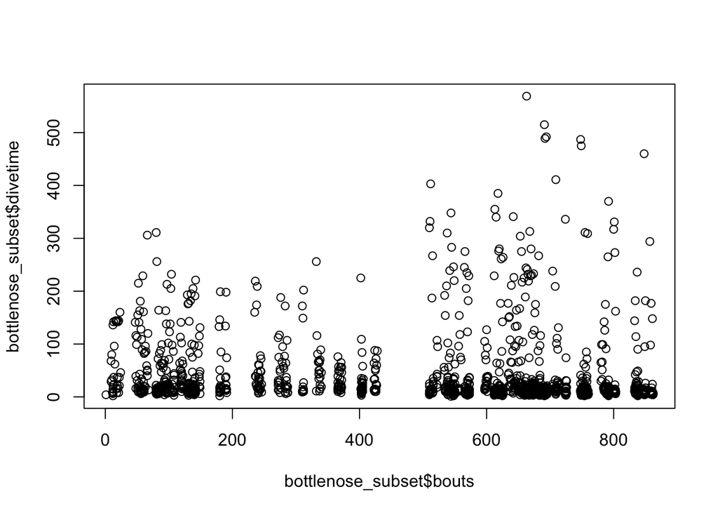

```r
plot(x = bottlenose_subset$bouts, y = bottlenose_subset$divetime)
```

### Challenge

Plot only the values from rows 21 to 45.